# Práctica calificada 1: Desarrollo Grupal

1. Suba la base de datos a utilizar a un repositorio de GitHub, cárguela y presente una breve descripción (1pt). De no contar con base para trabajo, puede revisar la página de Kaggle.com.

```r
library(rio)
BaseDistrital=import("https://github.com/ChiaraZamoraM/RDiplomatura/raw/main/BaseDistrital.csv")
```

```r
str(BaseDistrital)
```

```
## 'data.frame':    1874 obs. of  28 variables:
##  $ V1                 : int  1 2 3 4 5 6 7 8 9 10 ...
##  $ ubigeo_reniec2     : int  10101 10102 10103 10104 10105 10106 10107 10108 10109 10110 ...
##  $ id_ubigeo_domicilio: int  1 2 3 4 5 6 7 8 9 10 ...
##  $ Vac31Dic           : int  19064 255 684 508 717 1007 395 351 3169 2040 ...
##  $ Poblacion18        : int  20886 282 985 594 843 1554 452 431 4020 2652 ...
##  $ ubigeo_reniec      : int  10101 10102 10103 10104 10105 10106 10107 10108 10109 10110 ...
##  $ ubigeo_inei        : int  10101 10102 10103 10104 10105 10106 10107 10108 10109 10110 ...
##  $ departamento_inei  : int  1 1 1 1 1 1 1 1 1 1 ...
##  $ departamento       : chr  "AMAZONAS" "AMAZONAS" "AMAZONAS" "AMAZONAS" ...
##  $ provincia_inei     : int  101 101 101 101 101 101 101 101 101 101 ...
##  $ provincia          : chr  "CHACHAPOYAS" "CHACHAPOYAS" "CHACHAPOYAS" "CHACHAPOYAS" ...
##  $ distrito           : chr  "CHACHAPOYAS" "ASUNCION" "BALSAS" "CHETO" ...
##  $ region             : chr  "AMAZONAS" "AMAZONAS" "AMAZONAS" "AMAZONAS" ...
##  $ macroregion_inei   : chr  "ORIENTE" "ORIENTE" "ORIENTE" "ORIENTE" ...
##  $ macroregion_minsa  : chr  "MACROREGION ORIENTE" "MACROREGION ORIENTE" "MACROREGION ORIENTE" "MACROREGION ORIENTE" ...
##  $ iso_3166_2         : chr  "PE-AMA" "PE-AMA" "PE-AMA" "PE-AMA" ...
##  $ fips               : int  1 1 1 1 1 1 1 1 1 1 ...
##  $ superficie         : int  154 26 357 57 143 279 181 49 380 373 ...
##  $ altitud            : int  2338 2823 859 2143 2677 2803 3041 2591 2869 2226 ...
##  $ latitud            : num  -6.23 -6.03 -6.84 -6.26 -6.08 ...
##  $ longitud           : num  -77.9 -77.7 -78 -77.7 -77.7 ...
##  $ pob_distrito       : int  31382 345 1421 769 1044 2204 587 527 6141 3745 ...
##  $ pob_provincia      : int  59346 59346 59346 59346 59346 59346 59346 59346 59346 59346 ...
##  $ pob_departamento   : int  477514 477514 477514 477514 477514 477514 477514 477514 477514 477514 ...
##  $ diresa             : chr  "AMAZONAS" "AMAZONAS" "AMAZONAS" "AMAZONAS" ...
##  $ Avance             : num  91.3 90.4 69.4 85.5 85.1 ...
##  $ Ganador1           : chr  "PARTIDO POLITICO NACIONAL PERU LIBRE" "ACCION POPULAR" "PARTIDO POLITICO NACIONAL PERU LIBRE" "ACCION POPULAR" ...
##  $ Ganador2           : chr  "PARTIDO POLITICO NACIONAL PERU LIBRE" "PARTIDO POLITICO NACIONAL PERU LIBRE" "PARTIDO POLITICO NACIONAL PERU LIBRE" "PARTIDO POLITICO NACIONAL PERU LIBRE" ...
```

La base de datos “BaseDistrital” contiene, entre otras variables, el partido ganador de la primera (Ganador1) y el partido ganador de la segunda vuelta (Ganador2) de las Elecciones Generales 2021. Asimismo contiene el porcentaje de personas mayores de 18 completamente vacunadas (Avance).Para conocer cómo se consiguieron las variables puede revisar el RMD “Limpieza_TrabajoFinal”.

2. Planteamiento del problema y pregunta de investigación, objetivo principal y objetivos secundarios (1pt).

**Pregunta y subpreguntas de investigación**

A diciembre de 2021, ¿cuál era el avance acumulado de la vacunación en los distritos según el partido con mayoría de votos válidos en la primera y segunda vuelta de las Elecciones Generales 2021?

- Hacia la segunda vuelta de las EG 2021, ¿existía diferencia en el avance de la vacunación entre los distritos en los que ganó Pedro Castillo y en los que lo hizo Keiko Fujimori?
- Tras asumir la Presidencia de la República Pedro Castillo, ¿el avance de la vacunación ha favorecido a los distritos en los que ganó Perú Libre?

**Objetivo principal y objetivos secundarios**

Determinar si, a diciembre de 2021, el avance acumulado de la vacunación era similar en los distritos en los que ganó Perú Libre respecto a aquellos en los que lo hizo Fuerza Popular.

- Determinar si, hacia la segunda vuelta de las EG 2021, los distritos en los que ganó Pedro Castillo tenían un menor avance en la vacunación que los distritos en los que ganó Keiko Fujimori.
- Determinar si, tras asumir la Presidencia de la República Pedro Castillo, la vacunación no ha favorecido a los distritos en los que ganó Perú Libre.
3. Análisis exploratorio de las principales variables que se utilizarán para la app (3pt).

```r
library(tidyverse)
Elecciones1= BaseDistrital %>%
  group_by(Ganador1) %>%
   summarise(mean =  mean(Avance),
             wm = sum(Poblacion18*Avance)/sum(Poblacion18))
Elecciones1$Vuelta="Primera vuelta"

Elecciones2= BaseDistrital %>%
  group_by(Ganador2) %>%
   summarise(mean =  mean(Avance),
             wm = sum(Poblacion18*Avance)/sum(Poblacion18))
Elecciones2$Vuelta="Segunda vuelta"

EleccionesVacuna=merge(Elecciones1, Elecciones2, all=TRUE, by.x=c("Ganador1","mean","wm","Vuelta"),
                       by.y=c("Ganador2","mean","wm","Vuelta"))
```

```r
str(EleccionesVacuna)
```

```
## 'data.frame':    13 obs. of  4 variables:
##  $ Ganador1: chr  "ACCION POPULAR" "ALIANZA PARA EL PROGRESO" "AVANZA PAIS - PARTIDO DE INTEGRACION SOCIAL" "FUERZA POPULAR" ...
##  $ mean    : num  76.3 76.6 81.4 79.1 79.2 ...
##  $ wm      : num  68.9 79.8 81.7 80.7 78.8 ...
##  $ Vuelta  : chr  "Primera vuelta" "Primera vuelta" "Primera vuelta" "Segunda vuelta" ...
```

```r
head(EleccionesVacuna)
```

|  | Ganador1 | mean | wm | Vuelta |
| --- | --- | --- | --- | --- |
| 1 | ACCION POPULAR | 76.29068 | 68.93319 | Primera vuelta |
| 2 | ALIANZA PARA EL PROGRESO | 76.63022 | 79.76766 | Primera vuelta |
| 3 | AVANZA PAIS - PARTIDO DE INTEGRACION SOCIAL | 81.37352 | 81.65782 | Primera vuelta |
| 4 | FUERZA POPULAR | 79.14746 | 80.68154 | Segunda vuelta |
| 5 | FUERZA POPULAR | 79.23925 | 78.78663 | Primera vuelta |
| 6 | JUNTOS POR EL PERU | 84.26935 | 83.36402 | Primera vuelta |

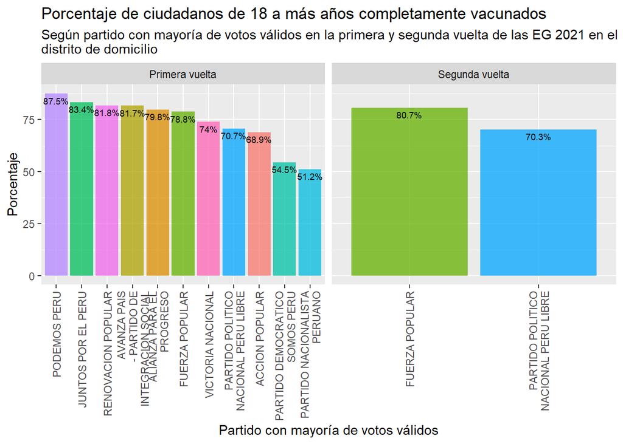

```r
Hipotesis1 = ggplot(EleccionesVacuna)+
  geom_bar(aes(x=reorder(Ganador1,-wm),y=wm,fill=Ganador1), stat="identity", alpha=0.75) +
  theme(axis.text.x = element_text(angle = 90, vjust = 0.5, hjust=1))+
  geom_text(aes(x=Ganador1,y=wm,label= paste0(round(wm,1),"%")),hjust=0.5, vjust=1.5, size=2.5) +
  labs(x="Partido con mayoría de votos válidos",y="Porcentaje", title="Porcentaje de ciudadanos de 18 a más años completamente vacunados",subtitle = "Según partido con mayoría de votos válidos en la primera y segunda vuelta de las EG 2021 en el \ndistrito de domicilio") +
  scale_x_discrete(labels = function(x) str_wrap(x, width = 20))+
  guides(fill=FALSE)+
  facet_wrap(~EleccionesVacuna$Vuelta, scales = "free_x")
Hipotesis1
```

```r
ggsave("Hipotesis.png", width = 8, height = 4)
```

1. Agregar a esta base los componentes del IDE.

```r
IDH=import("https://github.com/ChiaraZamoraM/RDiplomatura/raw/main/IDH%202019.xlsx")
```

```
## * `` -> ...2
## * `` -> ...3
## * `` -> ...4
## * `` -> ...5
## * `` -> ...6
## * ...
```

```r
colnames(IDH)= IDH[2,]
IDH=IDH[!is.na(IDH$UBIGEO),]
IDH=IDH[-1,c(1,7:10)]
IDH$UBIGEO=as.numeric(IDH$UBIGEO)
BaseDistrital2 = merge(BaseDistrital, IDH, by.x="ubigeo_inei", by.y="UBIGEO")
```

```r
library(psych)
library(tidyverse)
```

# ANÁLISIS FACTORIAL EXPLORATORIO

Aplicamos un análisis factorial exploratorio a la misma data

Vemos el número de factores recomendado:

```r
data= BaseDistrital2[,c(29:32)]
data= as.data.frame(sapply(data, as.numeric))
```

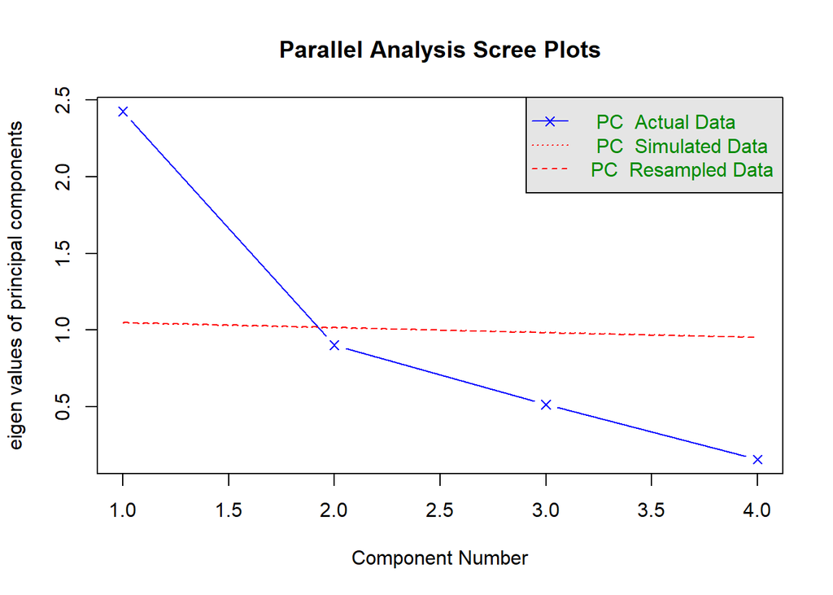

```
## Parallel analysis suggests that the number of factors =  NA  and the number of components =  1
```

```r
fa.parallel(data,fa="pc")
```

```r
pc <- prcomp(x=data,scale=TRUE, center=TRUE)
```

```r
BaseDistrital2<- BaseDistrital2 %>% mutate(pc1=pc$x[,1])
```

```r
summary(BaseDistrital2$pc1)
```

```
##    Min. 1st Qu.  Median    Mean 3rd Qu.    Max.
## -3.1490 -1.2236 -0.2907  0.0000  0.9978  5.4973
```

```r
summary(pc)
```

```
## Importance of components:
##                           PC1    PC2    PC3     PC4
## Standard deviation     1.5579 0.9499 0.7175 0.39483
## Proportion of Variance 0.6068 0.2256 0.1287 0.03897
## Cumulative Proportion  0.6068 0.8323 0.9610 1.00000
```

```r
pc$rotation
```

```
##                                                         PC1        PC2
## Esperanza de vida al nacer                        0.3018104 -0.8970022
## Población (18 años) con Educ. secundaria completa 0.4777732  0.4139416
## Años de educación (Poblac. 25 y más)              0.5955598  0.1519681
## Ingreso familiar per cápita                       0.5709218 -0.0307427
##                                                          PC3         PC4
## Esperanza de vida al nacer                        -0.3196663  0.04594575
## Población (18 años) con Educ. secundaria completa -0.7423650 -0.22198933
## Años de educación (Poblac. 25 y más)               0.2436911  0.75021920
## Ingreso familiar per cápita                        0.5360245 -0.62111261
```

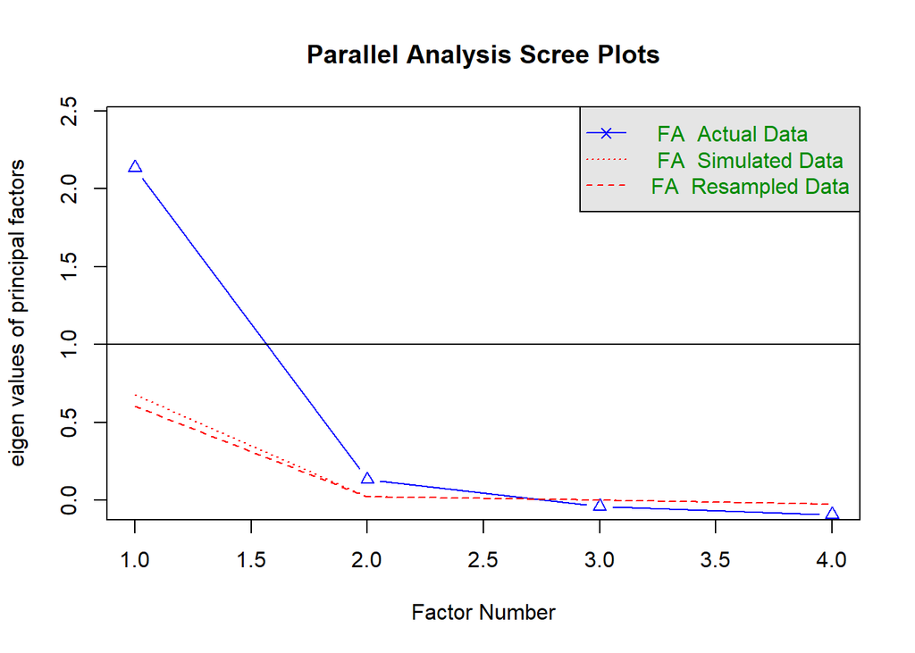

```
## Parallel analysis suggests that the number of factors =  2  and the number of components =  NA
```

```r
fa.parallel(data,fa="fa")
```

Calculamos el análisis factorial

```r
factorial <- fa(data,nfactors = 2,cor = 'mixed',rotate = "varimax",fm="minres")
```

Analizamos los resultados con:

```r
print(factorial$loadings)
```

```
##
## Loadings:
##                                                   MR1   MR2
## Esperanza de vida al nacer                        0.104 0.383
## Población (18 años) con Educ. secundaria completa 0.643 0.179
## Años de educación (Poblac. 25 y más)              0.838 0.499
## Ingreso familiar per cápita                       0.511 0.776
##
##                  MR1   MR2
## SS loadings    1.387 1.031
## Proportion Var 0.347 0.258
## Cumulative Var 0.347 0.605
```

Podemos visualizar los loadings más representativos.

```r
print(factorial$loadings,cutoff = 0.5)
```

```
##
## Loadings:
##                                                   MR1   MR2
## Esperanza de vida al nacer
## Población (18 años) con Educ. secundaria completa 0.643
## Años de educación (Poblac. 25 y más)              0.838
## Ingreso familiar per cápita                       0.511 0.776
##
##                  MR1   MR2
## SS loadings    1.387 1.031
## Proportion Var 0.347 0.258
## Cumulative Var 0.347 0.605
```

Podemos visualizar los variables y su relación con las latentes creadas:

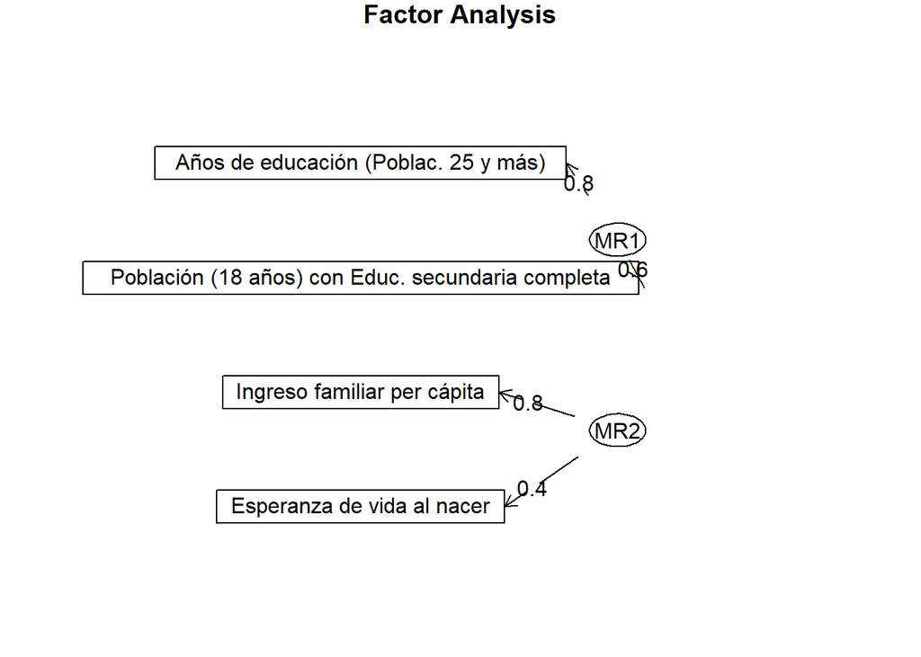

```r
fa.diagram(factorial)
```

```r
saveRDS(BaseDistrital2,"BaseDistrital2.RDS")
```

```r
BaseDistrital2=BaseDistrital2[,c("ubigeo_inei","departamento","provincia",
                                 "distrito","Avance","Ganador1","Ganador2","pc1")]
```

```r
library(sf)
```

```r
library(ggplot2)
library(ggpubr)
library(tidyverse)
library(ggrepel)
library(repr)
library(rjson)
mapa <- st_read("C:/Users/soyma/Documents/GitHub/RDiplomatura/LIMITE_DISTRITAL_2020_INEI_geogpsperu_juansuyo_931381206.shp")
mapa$UBIGEO=as.numeric(mapa$UBIGEO)

mapadist = merge(mapa, BaseDistrital2, by.x= "UBIGEO", by.y="ubigeo_inei")
```

```r
mapadist1 =mapadist %>% spread(Ganador1, Avance)
```

```r
mapadist2 =mapadist %>% spread(Ganador2, Avance)
```

```r
saveRDS(mapadist1,"MapaDist1.RDS")
```

```r
saveRDS(mapadist,"MapaDist.RDS")
```

```r
base1 = ggplot(data = mapadist) + theme_light()
```

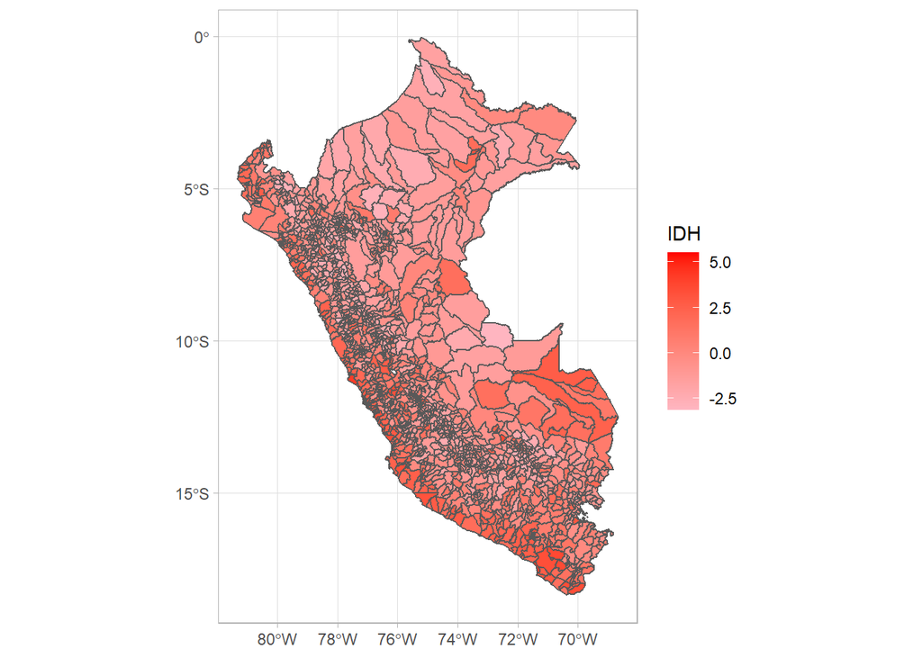

```r
mapaIDH = base1 +
  geom_sf(aes(fill= pc1), colour = NA) + labs(fill = "IDH") +
  geom_sf(data = mapadist,
          fill = NA) +
  scale_fill_gradient(low = "lightpink",  high = "red")


mapaIDH
```

```r
base2 = ggplot(data = mapadist) + theme_light()
```

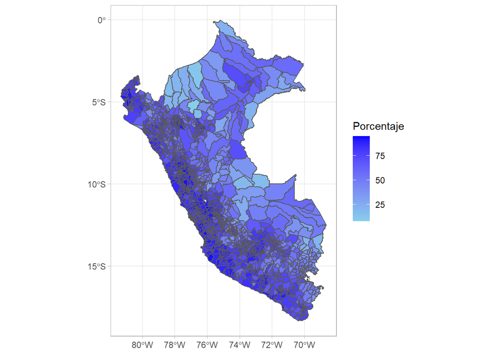

```r
mapaVacunacion = base2 +
  geom_sf(aes(fill= Avance)) + labs(fill = "Porcentaje") +
  geom_sf(data = mapadist,
          fill = NA) +
  scale_fill_gradient(low = "skyblue",  high = "blue")


mapaVacunacion
```

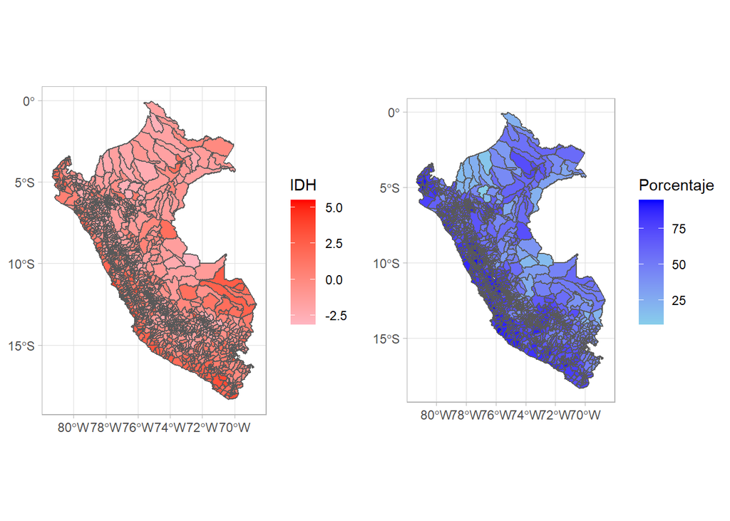

```r
ggarrange(mapaIDH, mapaVacunacion, nrow=1)
```